# Twitter Text Mining

**Introduction**

In this project, I worked with a team of 4 behavioral scientists to investigate how to properly classify tweets from two prominent politicians: Boris Johnson and Alexandria Ocasio-Cortez (AOC).

We sought to answer the research question: “How will the Twitter behavior of Boris Johnson and Alexandra Ocasio-Cortez compare and contrast?”. Specifically, we were interested in understanding how the content of the two politicians differ both in content and in scope. We specifically chose to compare these two individuals because, despite both being known widely as politicians, they are reasonably different from each other in their views and, thus, in the topics/opinions that they share on social media.

Johnson and Ocasio-Cortez are seen by the public as more than politicians, each has become a personality and a representative of politics in their respective nations and has experienced a great deal of social media attention.

Because Twitter offers a platform for a wide variety of topics (political and apolitical), we aimed to understand how these two similar yet very different people used the platform.

Below are our methodology, results, and conlusions in more detail:

**Methodology:**

two main steps: (i) a first step in R to get twitter data from our selected users (Boris Johnson and AOC) and (ii) a second step in Python to create the predictive algorithm.

(i) Downloading Twitter data in R

- We downloaded 3,200 tweets by Boris Johnson and AOC respectively.

````
```{r setup, include=FALSE}
#recovering tweets from our chosen people: Boris Johnson and AOC
library(rtweet)
## select one or more twitter users to lookup
users <- c("BorisJohnson", "aoc")
## get users data
usr_df <- lookup_users(users)
## view users data
usr_df
## view tweet data for these users via tweets_data()
tweets_data(usr_df)
bj <- get_timeline("BorisJohnson",  n=3200)
aoc <- get_timeline("aoc", n=3200)
```
````

- We excluded retweets, keeping only the variables that we were interested in using to develop our algorithm and selected a smaller sample of 200 tweets per user.
- We merged these two clean datasets into one in order to create an input file that could be used as an input for our algorithm (see ii).
- The output from this step is a .csv file including 400 tweets (200 tweets per selected user)

````
```{r pressure, echo=FALSE}
library(dplyr)
#selecting only relevant variables ('select')
#selecting only 200 rows from each person (as in the class exercise)
bj %>%  filter(is_retweet=="FALSE") %>%
  select("screen_name","text") %>%  #, "created_at"
  head(200) -> bj2
aoc %>%  filter(is_retweet=="FALSE") %>%
  select("screen_name","text") %>%  #, "created_at"
  head(200) -> aoc2
#creating one file with tweets from both people
tweets_hw9 <- union(bj2,aoc2)
tweets_hw9 %>% mutate(id = row_number()) %>% rename(author = screen_name, status = text) -> tweets_hw9_v0.2
#write.csv(tweets_hw9_tidy, "~/V/penn/Spring2021/516/")
write.csv(tweets_hw9_v0.2, file = "tweets_hw9_tidy.csv")
```
````

(ii) Creating Algorithm in Python

- We developed an algorithm that allowed us to predict whether the author of a given tweet was either Boris Johnson or AOC.
- The model takes our CSV output from step (i) as an input and splits the data into training and test data, then vectorizes our data (CountVectorizer and TfidfVectorizer)

```python
# Set seed for reproducibility
import random; random.seed(53)

# Import all we need from sklearn
from sklearn.feature_extraction.text import CountVectorizer, TfidfVectorizer
from sklearn.model_selection import train_test_split
from sklearn.naive_bayes import MultinomialNB
from sklearn.svm import LinearSVC
from sklearn import metrics
```

```python
import pandas as pd

# Load data
tweet_df = pd.read_csv('tweets_hw9_tidy.csv')

# Create target
y = tweet_df.author

# Split training and testing data
X_train, X_test, y_train, y_test = train_test_split(tweet_df['status'], y, test_size=0.33,
                 random_state=53)
```

```python
# Initialize count vectorizer
count_vectorizer = CountVectorizer(stop_words='english',
                                   min_df=0.05, max_df=0.9)

# Create count train and test variables
count_train = count_vectorizer.fit_transform(X_train)
count_test = count_vectorizer.transform(X_test)

# Initialize tfidf vectorizer
tfidf_vectorizer = TfidfVectorizer(stop_words='english',
                                   min_df=0.05, max_df=0.9)

# Create tfidf train and test variables
tfidf_train = tfidf_vectorizer.fit_transform(X_train)
tfidf_test = tfidf_vectorizer.transform(X_test)
```

- Following vectorization of the data, we trained a multinomial naive Bayes model with both the CountVectorizer and TfidfVectorizer data to see which would perform better
- To assess the accuracies, we printed the test sets accuracy scores for both models and found the CountVectorizer to be more accurate in its application, however, we must note that CountVectorizer outputs a vector with the number of times each word appears in the document which leads to a few problems: primarily that common words like “a”,”the”,”and”,”an” etc will appear most of the time and other words that carry the topic information of the tweet will be less frequent.

```python
tfidf_nb = MultinomialNB()
tfidf_nb.fit(tfidf_train, y_train)
tfidf_nb_pred = tfidf_nb.predict(tfidf_test)
tfidf_nb_score = metrics.accuracy_score(y_test, tfidf_nb_pred)

count_nb = MultinomialNB()
count_nb.fit(count_train, y_train)
count_nb_pred = count_nb.predict(count_test)
count_nb_score = metrics.accuracy_score(y_test, count_nb_pred)

print('NaiveBayes Tfidf Score: ', tfidf_nb_score)
print('NaiveBayes Count Score: ', count_nb_score)
```

```
NaiveBayes Tfidf Score:  0.6590909090909091
NaiveBayes Count Score:  0.6742424242424242
```

- We computed a few confusion matrices (without normalization) to further assess our model.

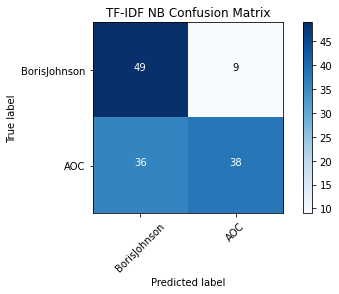

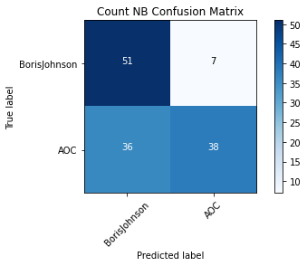

```python
%matplotlib inline
from helper_functions import plot_confusion_matrix

tfidf_nb_cm = metrics.confusion_matrix(y_test, tfidf_nb_pred, labels=['BorisJohnson', 'AOC'])
count_nb_cm = metrics.confusion_matrix(y_test, count_nb_pred, labels=['BorisJohnson', 'AOC'])

plot_confusion_matrix(tfidf_nb_cm, classes=['BorisJohnson', 'AOC'], title="TF-IDF NB Confusion Matrix")

plot_confusion_matrix(count_nb_cm, classes=['BorisJohnson', 'AOC'], title="Count NB Confusion Matrix", figure=1)
```

- After seeing the results of the Bayesian model, we tried a different approach: LinearSVC, another popular choice for text classification.
- We found that the LinearSVC model's accuracy was even better than the Multinomial Bayesian classifier.

```
LinearSVC Score:   0.720
```

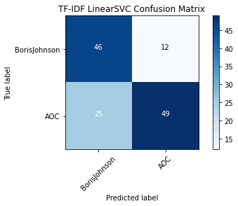

```python
tfidf_svc = LinearSVC()
tfidf_svc.fit(tfidf_train, y_train)
tfidf_svc_pred = tfidf_svc.predict(tfidf_test)
tfidf_svc_score = metrics.accuracy_score(y_test, tfidf_svc_pred)

print("LinearSVC Score:   %0.3f" % tfidf_svc_score)

svc_cm = metrics.confusion_matrix(y_test, tfidf_svc_pred, labels=['BorisJohnson', 'AOC'])
plot_confusion_matrix(svc_cm, classes=['BorisJohnson', 'AOC'], title="TF-IDF LinearSVC Confusion Matrix")
```

```python
from helper_functions import plot_and_return_top_features

from pprint import pprint
top_features = plot_and_return_top_features(tfidf_svc, tfidf_vectorizer)
pprint(top_features)
```

- To better understand what the model had learned, we used the LinearSVC Classifier to sort the features (words) of the two classes (Boris and AOC), by their weight.
- Doing so enabled us to see the most important words for both Boris and AOC, thus being able to determine what the most Boris-like or AOC-like words were (in the hopes of learning something useful to distinguish between the two public figures)
- In the image below, Boris's frequent words are represented in blue, while AOC's are represented in red

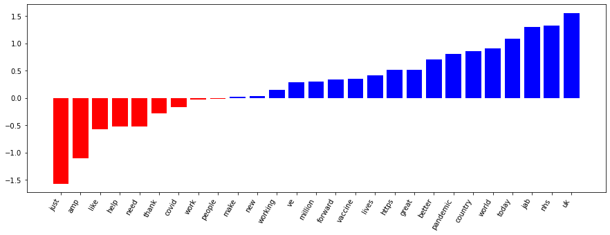

```
[(-1.571392067953188, 'just'),
 (-1.1081256082301203, 'amp'),
 (-0.5709361310238537, 'like'),
 (-0.5282400586634044, 'help'),
 (-0.5213708458929962, 'need'),
 (-0.2883752457487016, 'thank'),
 (-0.17555190473254842, 'covid'),
 (-0.025633038788300512, 'work'),
 (-0.019639070500012328, 'people'),
 (0.026298404989680176, 'make'),
 (0.0358824501939278, 'new'),
 (0.15135247316088693, 'working'),
 (0.2867149307391597, 've'),
 (0.30155929094176087, 'million'),
 (0.3426410233098148, 'forward'),
 (0.3445520396961667, 'vaccine'),
 (0.41377319240035, 'lives'),
 (0.5102228502056371, 'https'),
 (0.5125884767050534, 'great'),
 (0.7070527266308251, 'better'),
 (0.8057513962806446, 'pandemic'),
 (0.8574625155330323, 'country'),
 (0.901389484928821, 'world'),
 (1.0891169886420076, 'today'),
 (1.2961682523710378, 'jab'),
 (1.3219768155203768, 'nhs'),
 (1.5555764389888034, 'uk')]
```

- The last few chunks of code allow us to manually test whether a tweet we input belongs to one individual or the other by predicting whether the given sentence is more likely to be tweeted by Boris Johnson or by AOC.

```python
tweet = "I would like to send my warm wishes to Her Majesty The Queen on her 95th birthday."


tweet_vectorized = tfidf_vectorizer.transform([tweet])


tweet_pred = tfidf_svc.predict(tweet_vectorized)


print("Predicted Speaker", tweet_pred)


#Tweets for Manual Test

#This is the story of the UK vaccine rollout which has already saved thousands of lives.
#Tweeted by: BJ
#Predicted: BJ

#The world’s tropical forests are the lungs of our planet and yet we’re losing these great, teeming ecosystems at an unconscionable rate. I’m pleased the UK is joining this hugely exciting coalition to protect our tropical forests and tackle climate change.
#Tweeted by: BJ
#Predicted: BJ

#We can build back better from this pandemic by building back greener.
#Tweeted by: BJ
#Predicted: BJ

#In supporting #StephenLawrenceDay we are reminded of Stephen's many talents, and our duty to stop racism and give young people the best possible future.My thoughts are with Stephen’s parents Doreen and Neville, and the many families that have lost loved ones in their prime.
#Tweeted by: BJ
#Predicted: AOC
#!! Error

#I would like to send my warm wishes to Her Majesty The Queen on her 95th birthday.
#Tweeted by: BJ
#Predicted: AOC
#!! Error

#Last January I was sworn in for my first term in Congress.
#Tweeted by: AOC
#Predicted: AOC

#Yes! And as we continue the fight for #MedicareForAll nationally, did you know that progressives established a key step for M4A here at home & across NYC?
#Tweeted by: AOC
#Predicted: AOC

#I’m glad you like it @chelliepingree! Happy Earth Day Earth globe americas
#Tweeted by: AOC
#Predicted: AOC

#That a family had to lose a son, brother and father; that a teenage girl had to film and post a murder, that millions across the country had to organize and march just for George Floyd to be seen and valued is not justice.
#Tweeted by: AOC
#Predicted: AOC

#I welcome the Court of Appeal's decision to overturn the convictions of 39 former sub-postmasters in the Horizon dispute, an appalling injustice which has had a devastating impact on these families for years.
#Tweeted by: AOC
#Predicted: BJ
#!! Error
```

```
Predicted Speaker ['AOC']
```

```python
#Unrelated users test

test_tweet = "Buckingham Palace have released a new picture of Queen Elizabeth in celebration of her 95th birthday."

test_tweet_vectorized = tfidf_vectorizer.transform([test_tweet])

test_tweet_pred = tfidf_svc.predict(test_tweet_vectorized)

print("Predicted test tweet", test_tweet_pred)

#Tweet for unrelated users manual test:

#Get vaccinated, folks.
#Tweeted by: President Biden
#Predicted: AOC

#Your answer to the dreaded low battery. #GalaxyS21 5G intuitively manages your usage so you never miss a moment.
#Tweeted by: Samsung Mobile US
#Predicted: AOC

#Am hosting SNL on May 8
#Tweeted by: Elon Musk
#Predicted: AOC

#It’s the Championship - all or nothing. Choose your team before the games start.
#Tweeted by: Wendy's
#Predicted: AOC

#Buckingham Palace have released a new picture of Queen Elizabeth in celebration of her 95th birthday.
#Tweeted by: The Telegraph
#Predicted: AOC
```

```
Predicted test tweet ['AOC']
```

**Results**

To assess our model's accuracy, we trained it with past tweets from both users and computed a number of Confusion Matrices, then tested it with new tweets from the two users as well with tweets from unrelated users.

The Confusion Matrices showed us that the algorithm developed from our train data was better at predicting tweets by Boris Johnson compared to those by AOC (when comparing the predicted vs true tweet axes). Perhaps this is because AOC uses broader language when she tweets.

When testing the model manually, we find that the model is pretty accurate: we test 10 new tweets (5 by BJ and 5 by AOC) and we find that the model accurately predicts 7/10 (~70% accuracy).

The model faltered, however, when we tested Tweets from unrelated users. Because AOC uses a wider spectrum of words than Boris, many of the unrelated Tweets were attributed to her by the algorithm. This included Tweets which contained content that would normally be associated with Boris. In this sense, the model ‘breaks’ when we test it with tweets by unrelated users.

**Conclusion**

In conclusion, we found that our algorithm was able to predict whether a given tweet was more likely tweeted by Boris Johnson or AOC with an accuracy of about 70%. This is both consistent with the results from the Confusion Matrices and with our manual test.

There were, notably, also considerable differences which allowed our algorithm to predict which user a Tweet came from. For example, Johnson, being the prime minister of the UK, frequently used the word "UK" unlike AOC. In all likelihood, if a tweet contained the word “ UK “, it was likely issued by Johnson.

As we look ahead, future work on this dataset can involve: i) further analysis of our model to determine what words are more Boris- or AOC-like and ii) the addition of more recent tweets to further train our dataset

**Acknowledgement**

This work is the result of a project by Samira Okudo, Nicolle Belaunde, Valentina Cafarelli, Jenifer M. Nemoda, and Jonathan Zur.

The predictive algorithm, on which it is based, is adapted from a model prepared by Alexander Shpenev (https://github.com/shpenev)